# RED WINE QUALITY EXPLORATION by Noopur Koshta

Number of Instances: red wine - 1599

Number of Attributes: 11 + output attribute = total 12 attributes(features + 1 feature introduced later ie. quality bins)

Attribute information: Input variables (based on physicochemical tests):

- Fixed acidity
- Volatile acidity
- Citric acid
- Residual sugar
- Chlorides
- Free sulfur dioxide
- Total sulfur dioxide
- Density
- pH
- Sulphates
- Alcohol

Output variable (based on sensory data):

- Quality (score between 0 and 10)
- Quality buckets(bad, normal, good, best)

Missing Attribute Values: None

# Univariate Plots Section

### Listing column names in the dataset

```
## 'data.frame':    1599 obs. of  13 variables:
##  $ SNo.                : int  1 2 3 4 5 6 7 8 9 10 ...
##  $ fixed.acidity       : num  7.4 7.8 7.8 11.2 7.4 7.4 7.9 7.3 7.8 7.5 ...
##  $ volatile.acidity    : num  0.7 0.88 0.76 0.28 0.7 0.66 0.6 0.65 0.58 0.5 ...
##  $ citric.acid         : num  0 0 0.04 0.56 0 0 0.06 0 0.02 0.36 ...
##  $ residual.sugar      : num  1.9 2.6 2.3 1.9 1.9 1.8 1.6 1.2 2 6.1 ...
##  $ chlorides           : num  0.076 0.098 0.092 0.075 0.076 0.075 0.069 0.065 0.073 0.071 ...
##  $ free.sulfur.dioxide : num  11 25 15 17 11 13 15 15 9 17 ...
##  $ total.sulfur.dioxide: num  34 67 54 60 34 40 59 21 18 102 ...
##  $ density             : num  0.998 0.997 0.997 0.998 0.998 ...
##  $ pH                  : num  3.51 3.2 3.26 3.16 3.51 3.51 3.3 3.39 3.36 3.35 ...
##  $ sulphates           : num  0.56 0.68 0.65 0.58 0.56 0.56 0.46 0.47 0.57 0.8 ...
##  $ alcohol             : num  9.4 9.8 9.8 9.8 9.4 9.4 9.4 10 9.5 10.5 ...
##  $ quality             : int  5 5 5 6 5 5 5 7 7 5 ...
```

```
##  [1] "SNo."                 "fixed.acidity"        "volatile.acidity"
##  [4] "citric.acid"          "residual.sugar"       "chlorides"
##  [7] "free.sulfur.dioxide"  "total.sulfur.dioxide" "density"
## [10] "pH"                   "sulphates"            "alcohol"
## [13] "quality"
```

### Summary of dataset

```
##  fixed.acidity   volatile.acidity  citric.acid    residual.sugar
##  Min.   : 4.60   Min.   :0.1200   Min.   :0.000   Min.   : 0.900
##  1st Qu.: 7.10   1st Qu.:0.3900   1st Qu.:0.090   1st Qu.: 1.900
##  Median : 7.90   Median :0.5200   Median :0.260   Median : 2.200
##  Mean   : 8.32   Mean   :0.5278   Mean   :0.271   Mean   : 2.539
##  3rd Qu.: 9.20   3rd Qu.:0.6400   3rd Qu.:0.420   3rd Qu.: 2.600
##  Max.   :15.90   Max.   :1.5800   Max.   :1.000   Max.   :15.500
##    chlorides       free.sulfur.dioxide total.sulfur.dioxide
##  Min.   :0.01200   Min.   : 1.00       Min.   :  6.00
##  1st Qu.:0.07000   1st Qu.: 7.00       1st Qu.: 22.00
##  Median :0.07900   Median :14.00       Median : 38.00
##  Mean   :0.08747   Mean   :15.87       Mean   : 46.47
##  3rd Qu.:0.09000   3rd Qu.:21.00       3rd Qu.: 62.00
##  Max.   :0.61100   Max.   :72.00       Max.   :289.00
##     density             pH          sulphates         alcohol
##  Min.   :0.9901   Min.   :2.740   Min.   :0.3300   Min.   : 8.40
##  1st Qu.:0.9956   1st Qu.:3.210   1st Qu.:0.5500   1st Qu.: 9.50
##  Median :0.9968   Median :3.310   Median :0.6200   Median :10.20
##  Mean   :0.9967   Mean   :3.311   Mean   :0.6581   Mean   :10.42
##  3rd Qu.:0.9978   3rd Qu.:3.400   3rd Qu.:0.7300   3rd Qu.:11.10
##  Max.   :1.0037   Max.   :4.010   Max.   :2.0000   Max.   :14.90
##     quality
##  Min.   :3.000
##  1st Qu.:5.000
##  Median :6.000
##  Mean   :5.636
##  3rd Qu.:6.000
##  Max.   :8.000
```

From the above summary of the data set, the ‘total SO2’ has a significant difference between their values which may mean that there are some outliers driving the mean; this we will explore in the further univariate plots.

```r
# Function to plot Univariate plots

plot.hist <- function(x.var, df, bw, x.lab, y.lab, title){
  ggplot(df, aes_string(x = x.var)) +
    geom_histogram(binwidth = bw) +
    xlab(x.lab) +
    ylab(y.lab) +
    ggtitle(title)
}
```

### Fixed acidity distribution

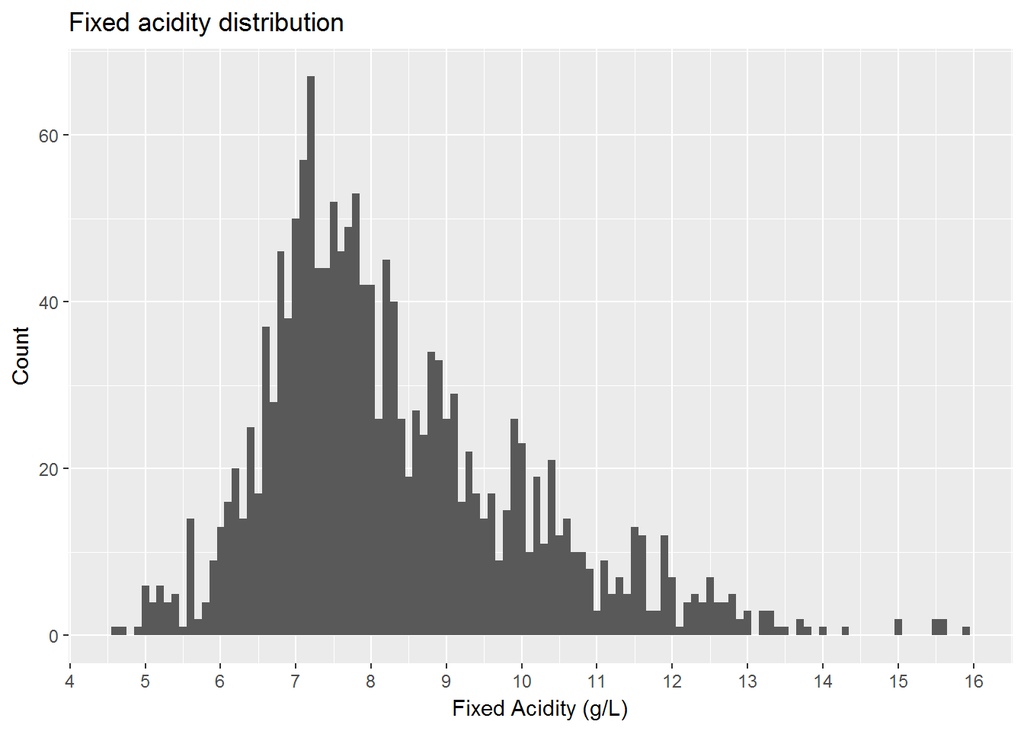

The fixed acidity shows a normal distribution with majority of the values lying between 6.5 g/L and 9.5 g/L. (According to the research papers referred, the unit of measurement turns out to be in g/L).

### Volatile acidity distribution

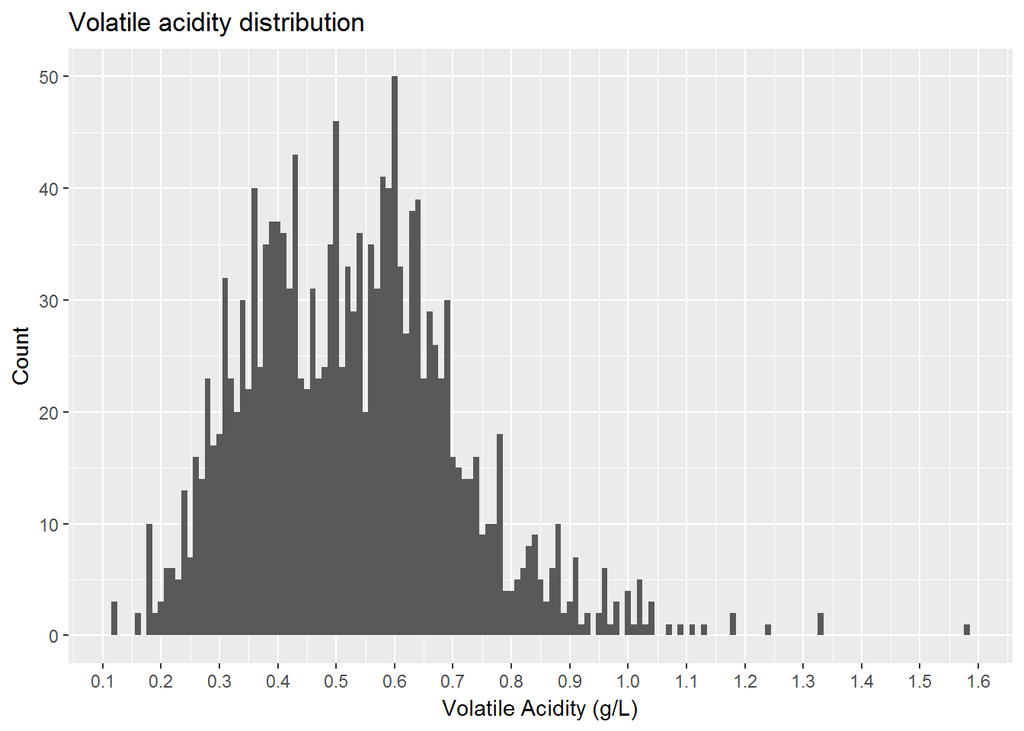

```
##
## 3 4 5 6
## 3 6 9 3
```

The volatile acidity shows a bimodal distribution (ie. modes near .4g/L and .6g/L approximately) with majority of the values lying between 0.25 g/L and 0.75 g/L, with few outliers after 1.0 g/L

Above 600 - 700 mg/L acetic acid/volatile acidity is noticeable and it depreciates wine quality.The legal limits in the U.S. for volatile acidity is 1,400 mg/L for red wines.

### Citric acid distribution

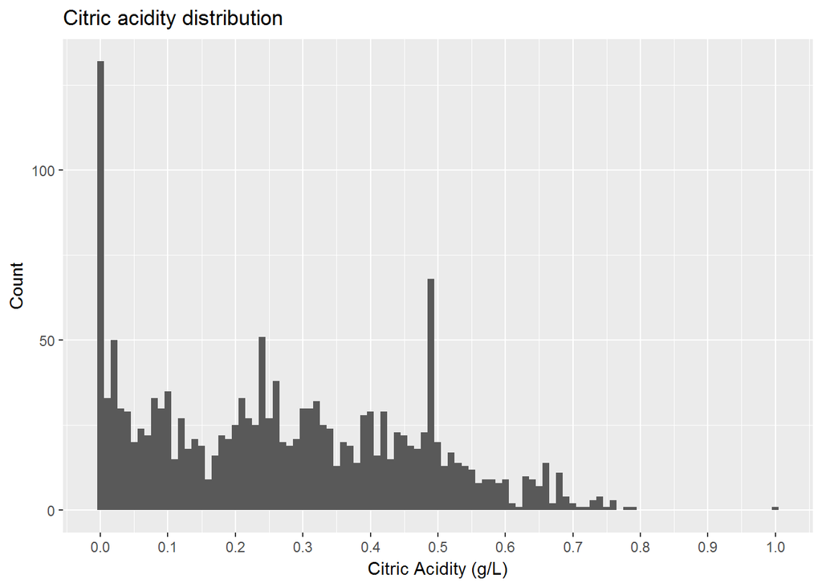

```
##
## 4 5 6 7 8
## 1 3 3 8 1
```

The citric acid values shows a bimodal distribution (ie. modes near 0.0 g/L and 0.5 g/L approximately) with majority of the values lying between 0.0 g/L and 0.5 g/L, with few outliers at 1.0 g/L.

Citric acid is a minor acid of grapes, appearing at levels up to 10% of the total acid content, or 0.1 g/L - 0.7 g/L. Thus, acid level more than 0.7 g/L might have increased with time, thus making wine more acidic. Shockingly, good quality wines are also having limits of this acid above than the required; this may not matter that much since it contributes to only 10% of the acid content in the wine, and thus not degrading the quality of wines much.

### Residual sugar distribution

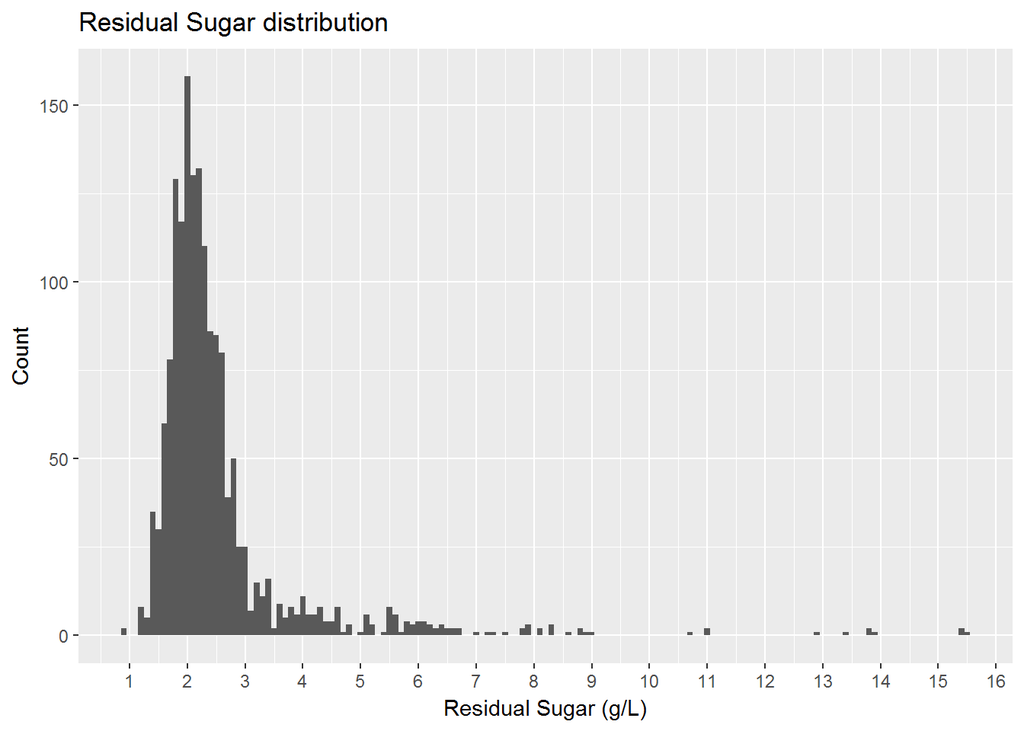

```
##
## 4 5 6
## 1 3 7
```

The residual sugar values shows a positively skewed distribution with majority of the values lying between 0 g/L and 3 g/L.

### Chlorides distribution

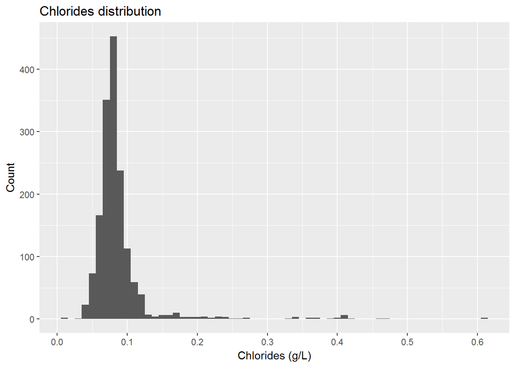

```
##
##  3  4  5  6  7
##  1  1 20 17  2
```

### Free sulfur dioxide distribution

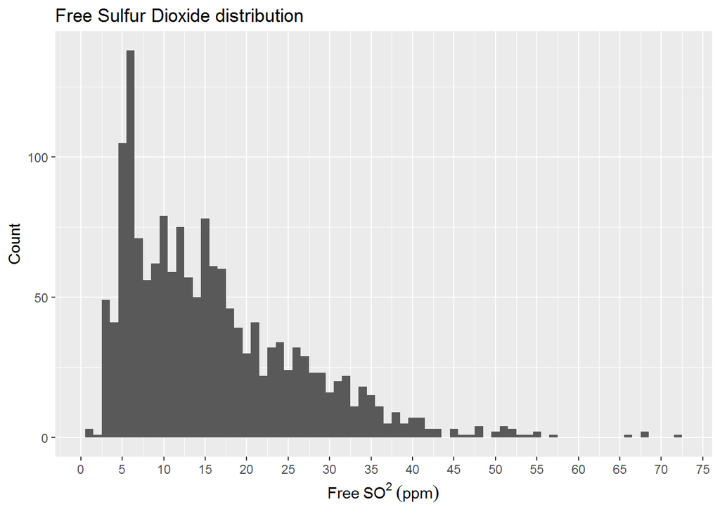

```
##
## 3.16 3.17 3.18  3.2 3.22 3.26 3.27 3.28  3.3 3.32 3.33 3.34 3.38 3.47 3.59
##    3    1    2    2    1    1    1    1    1    1    1    1    2    4    1
## 3.61
##    1
```

The free sulfur dioxide values shows a positively skewed distribution with majority of the values lying between 0.0 ppm and 30 ppm. It’s value is exponentially proportional to the pH of the wine. As the pH increases, the amount of free SO2 is addded accordingly to stabilize the wine’s pH, ie. to protect the wine from oxidizing. Thus, we can see pH in the range of 3-4 with higher free sulfur dioxide levels.

### Total sulfur dioxide distribution

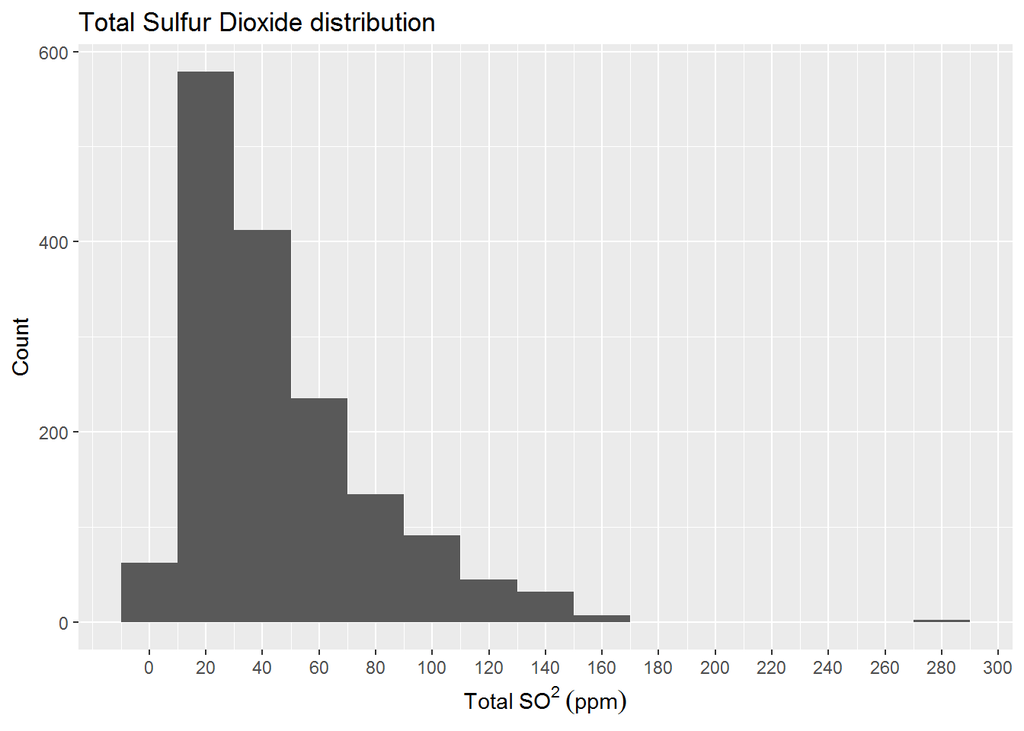

```
##
## 7
## 2
```

```
##
##  110  146  189  190  202  220  516  524  592  637  638  650  652  673  685
##    1    1    1    1    1    1    1    1    1    1    1    1    1    1    1
##  772  773 1080 1082 1401 1402 1494 1497
##    1    1    1    1    1    1    1    1
```

The total sulfur dioxide values shows a positively skewed distribution with majority of the values lying between 0.0 ppm and 80 ppm. The free SO2 eventually oxidizes and contributes in total SO2, where it is in inactive state. Over-sulfating the wine may cause the taste to degrade. Unexpectedly, the quality of red wines with over 260 ppm (outliers) is 7, thus we might at this moment assume that the other factors might have saved the wine’s quality from going down.

In the 2nd table results, we see that the tail in total sulfur dioxide is because of the free sulfur dioxide becoming inactive with time and thus became part of total sulfur dioxide.

### Density distribution

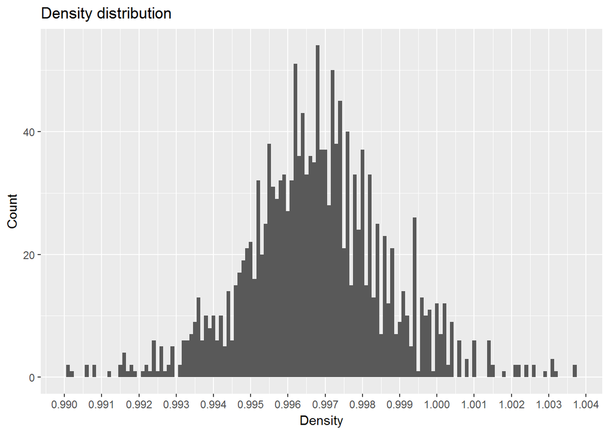

The density values shows a normal distribution with majority of the values lying between 0.995 and 0.999.

### pH distribution

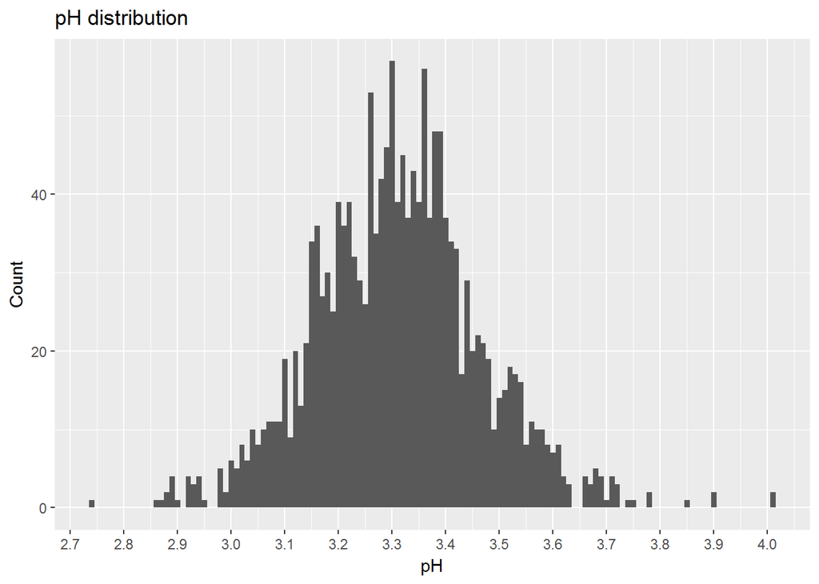

```
##
##   3   4   5   6   7   8
##   2  14 333 273 107  13
```

Some suggest the prefered pH range is 3.3-3.6, while others say it to be pH 3.4-3.7, for red wines. So, lets take 3.3 - 3.7 as the optimum pH range. But, we can see that many wine falling under good quality category also has pH ou of the optimum range!

### Sulphates distribution

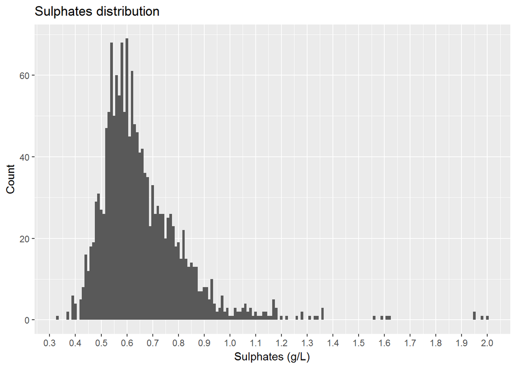

The sulphates values shows a positively skewed distribution with majority of the values lying between 0.5 g/L and 0.8 g/L.

### Alcohol distribution

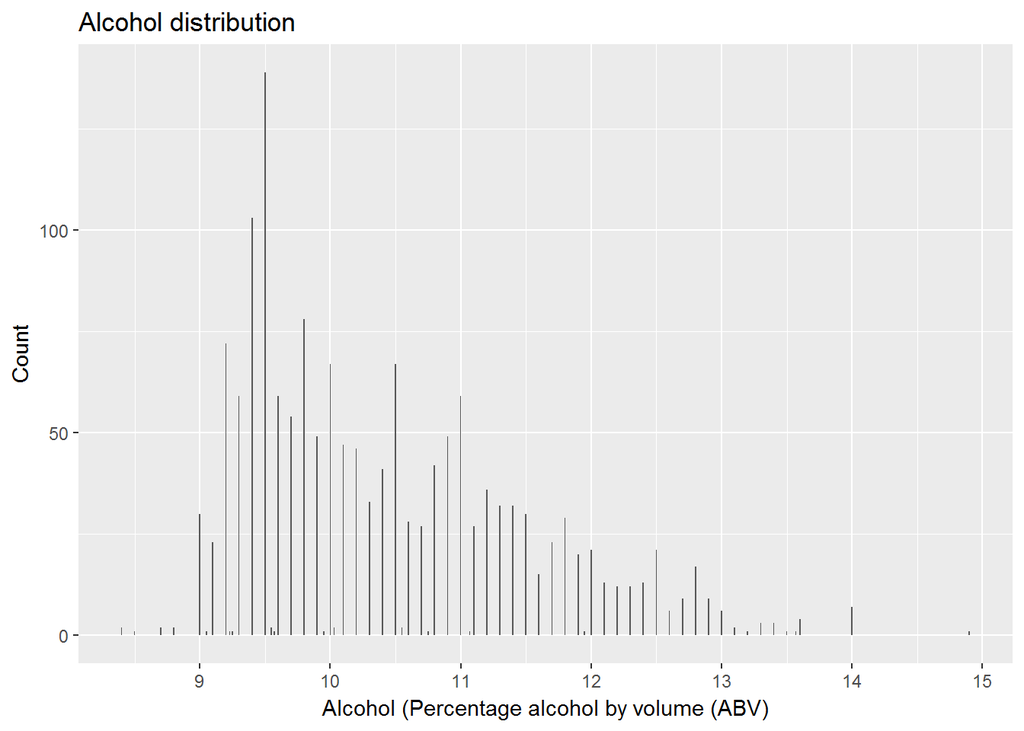

The alcohol values shows a positively skewed distribution with majority of the values lying between 9% and 11.5% alcohol by volume(ABV).

- Low Alcohol Wines: Below 10% ABV
- Medium-Low Alcohol Wines: 10-11.5% ABV
- Medium Alcohol Wines: 11.5%-13.5% ABV
- Medium-High Alcohol Wines: 13.5%-15% ABV
- High Alcohol Wines: Over 15% ABV

### Quality distribution

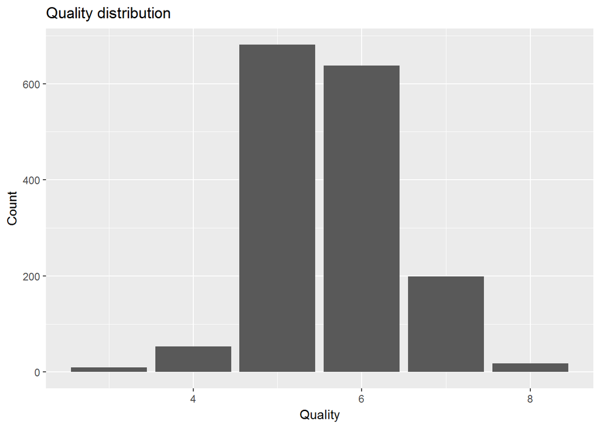

The quality values shows a normal distribution with majority of the values lying at 5 and 6 quality factors.

### Quality groups

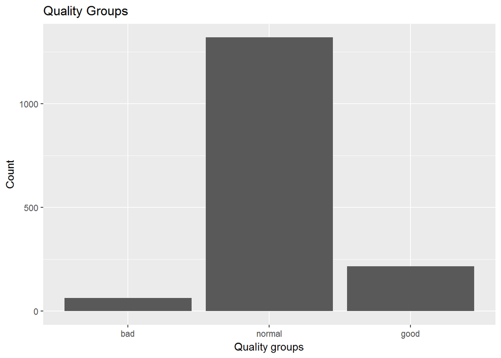

Here, segregation of quality factors into quality buckets have been done to label the red wines as bad, normal or good.

# Univariate Analysis

### What is the structure of your dataset?

- (0,4] - bad
- (4,6] - normal
- (6,8] - good
- (8,10] - best

Other observations:

- The tail in total sulfur dioxide is because of the free sulfur dioxide becoming inactive with time and thus became part of total sulfur dioxide.
- Most wines having pH in the range 3.1-3.5, with the mean and median of around 3.3 which is quite desirable.
- Most of the wines are of quality 5 and 6, and none of quality above 8.
- Most of the wines are low alcohol wines ie. below 10% ABV, followed by low-medium alcohol wines ie. 10%-11.5% ABV.

### What is/are the main feature(s) of interest in your dataset?

The main features in the data set are:

- Free and total SO2
- Alcohol
- Fixed and volatile acidity
- Quality

Quantity of SO2 (free and total) and acidity (both fixed and volatile) might be used to predict quality of wine.

### What other features in the dataset do you think will help support your investigation into your feature(s) of interest?

Apart from the above features, pH and density of wine might be helpful to predict the quality of wine.

### Did you create any new variables from existing variables in the dataset?

Yes. ‘quality.bucket’ is the variable created by me to segregate quality into 4 quality bins viz.,

- (0,4] - bad
- (4,6] - normal
- (6,8] - good
- (8,10] - best

### Of the features you investigated, were there any unusual distributions? Did you perform any operations on the data to tidy, adjust, or change the form of the data? If so, why did you do this?

I just named an unnamed column in the dataset ie. SNo. to refer to particular wines if required. Other than that, the dataset had no NA values.

# Bivariate Plots Section

### Correlation matrix

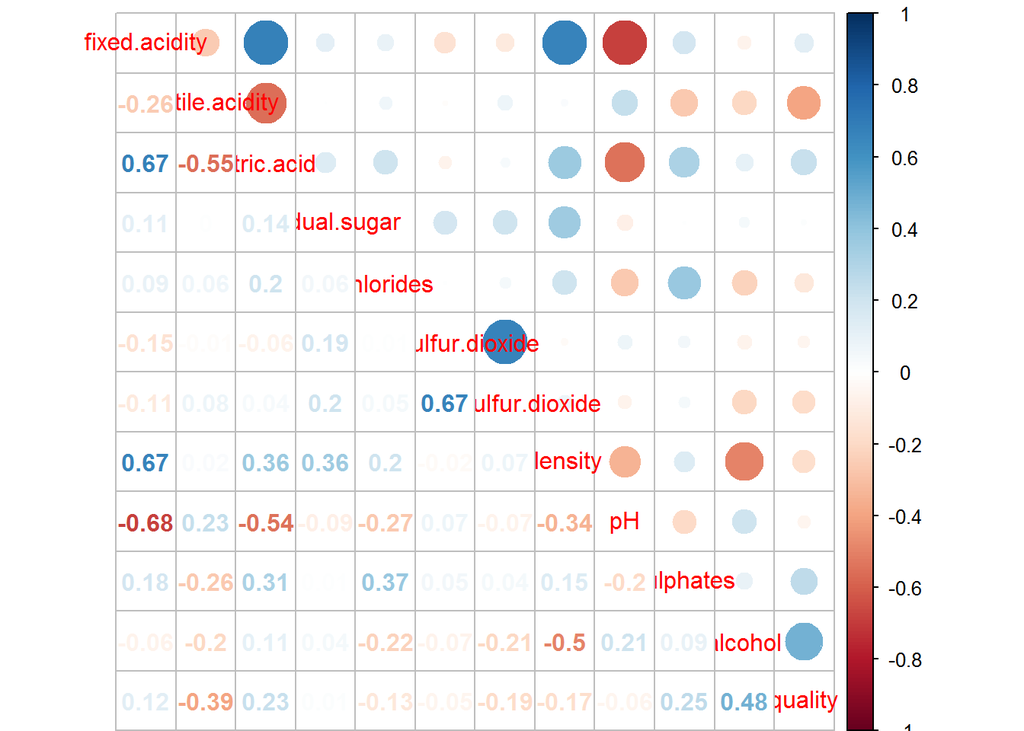

Using this mixed correlation matrix makes it easy to identify strong and weak correlations at first sight.

From above matrix, we see that:

- Fixed acidity and citric acid have strong correlation of 0.67, obviously.
- Free and total SO2 also have string correlation of 0.67, since free SO2 is ultimately becoming total SO2 after it becomes inactive.
- Density and fixed acidity are also having correlation of 0.67. Also, density and citric acid have a correlation of 0.36. Thus, this may mean that acids add density to the wine.
- Density and residual sugar are also having correlation of 0.36.
- Density and alcohol, on the other hand, have a correlation of -0.5.
- pH and fixed acidity has negatively correlated with correlation of -0.68, and this is because when acidity increases pH drops down. For the same reason, pH has negative correlation citric acid too.
- Surprisingly, pH doesn’t decrease with increase in volatile acidity, infact they have a correlation of 0.23.
- Quality is strongly correlated with alcohol and moderately correlated with citric acid and sulphates. Though it is negatively correlated with volatile acid, with correlation of -0.39.

### Proportion of wines of the particular pH

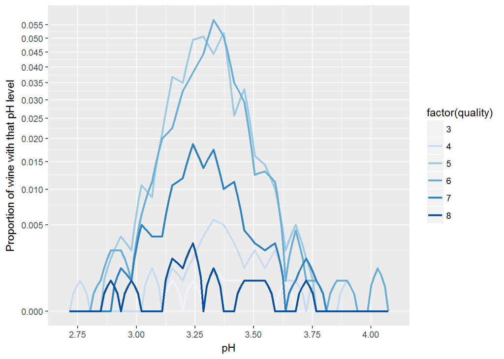

Major observations from this plot is:

Most of the wines of quality 5 & 6 are in the pH range 3.2-3.6, which is nearly desired pH range, but still they are not in ‘good’ quality bin! Thus, we’ll explore further what is making these wines of low quality.

### Alcohol vs Quality

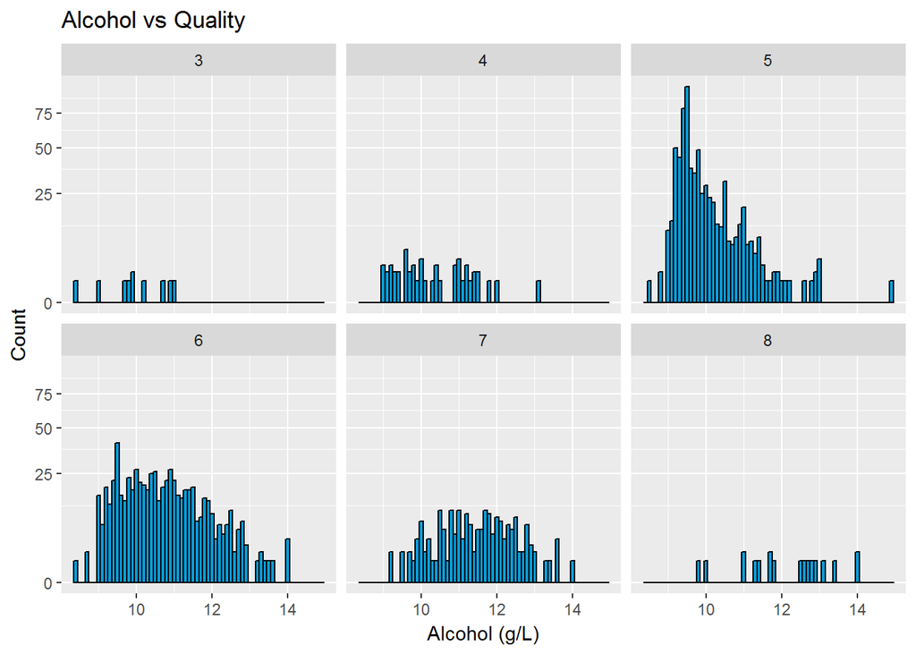

From the correlation matrix, we got correlation between alcohol and quality as 0.48. So, as alcohol level increases, more will be the quality should be the conclusion. But since this seems awkward, I think that more the alcohol content, more is the free sulfur dioxide required to stabilize the pH and preserve it for longer duration and thus the other acid contents are also contributing in the apt proportion to keep the wine stable and thus such might be the correlation betweeen alcohol and quality!

### pH vs Quality

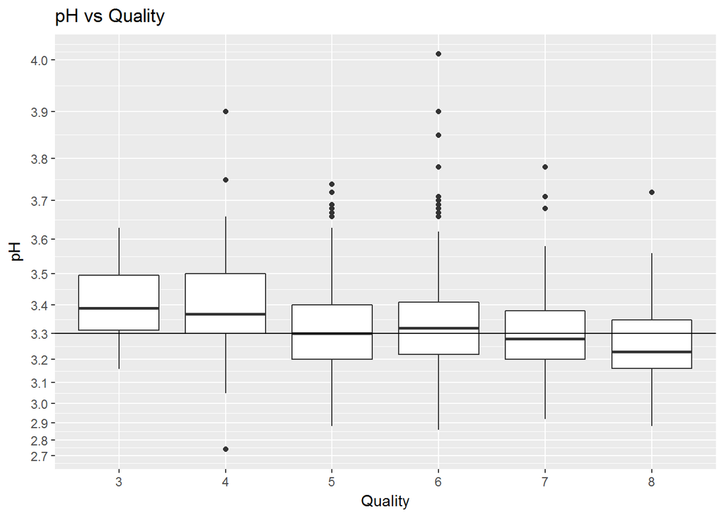

Since pH is already a log value, thus on taking the exponential transformation we get the above plot. The lower desirable limit of pH is 3.3, but even good quality wines don’t fulfil them, this may be because of the increase in the amount of free and total sulfur making the overall pH to go down, thus increasing the acidity of wine.

Currently winemakers in California are pushing wines to high pH levels, as high as 4.0, while 20 years ago pH’s above 3.6 were unusual. This makes wines taste softer, popular with wine writers today.

### Sulphates vs Quality

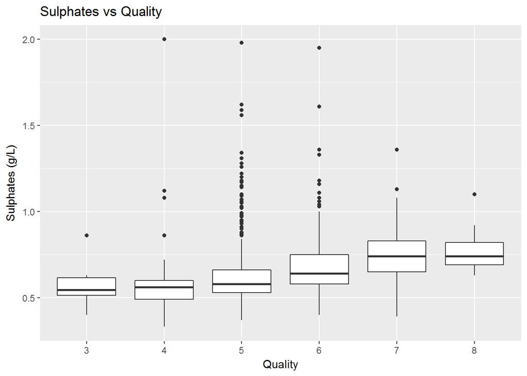

The good quality wines have higher sulphates levels and under 1 mmol/L, which is desirable, to prevent oxidation of wines.

### Chlorides vs Quality

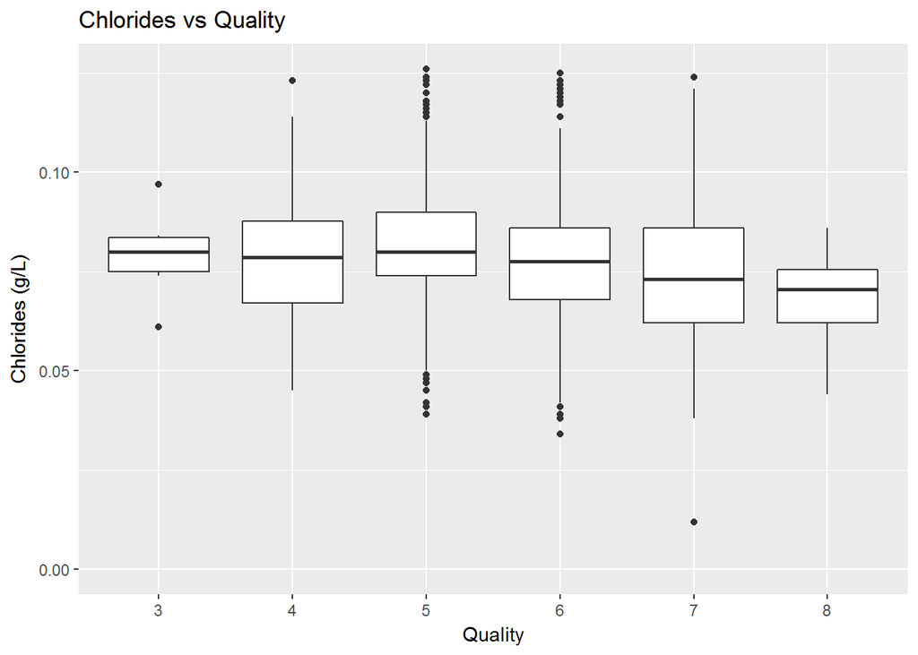

The maximum chloride levels allowed in most countries is 0.2 g/L, and it is a good thing that all wines are under this limit in our dataset.

### Citric acid vs Quality

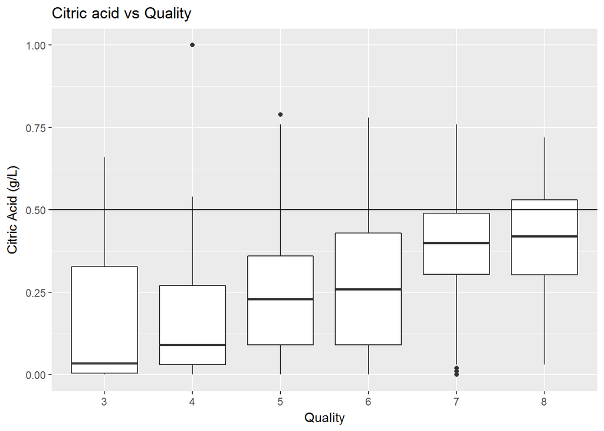

The predominant fixed acids found in wines are tartaric, malic, citric, and succinic. Their respective levels found in wine can vary greatly but in general one would expect to see 1,000 to 4,000 mg/L tartaric acid, 0 to 8,000 mg/L malic acid, 0 to 500 mg/L citric acid, and 500 to 2,000 mg/L succinic acid.

Now, again the recommended maximum citric acid limit is 0.5 g/L, but the good quality wines are having highest of all concentration and still the best wines! Let’s explore more.

### Volatile acidity vs Quality

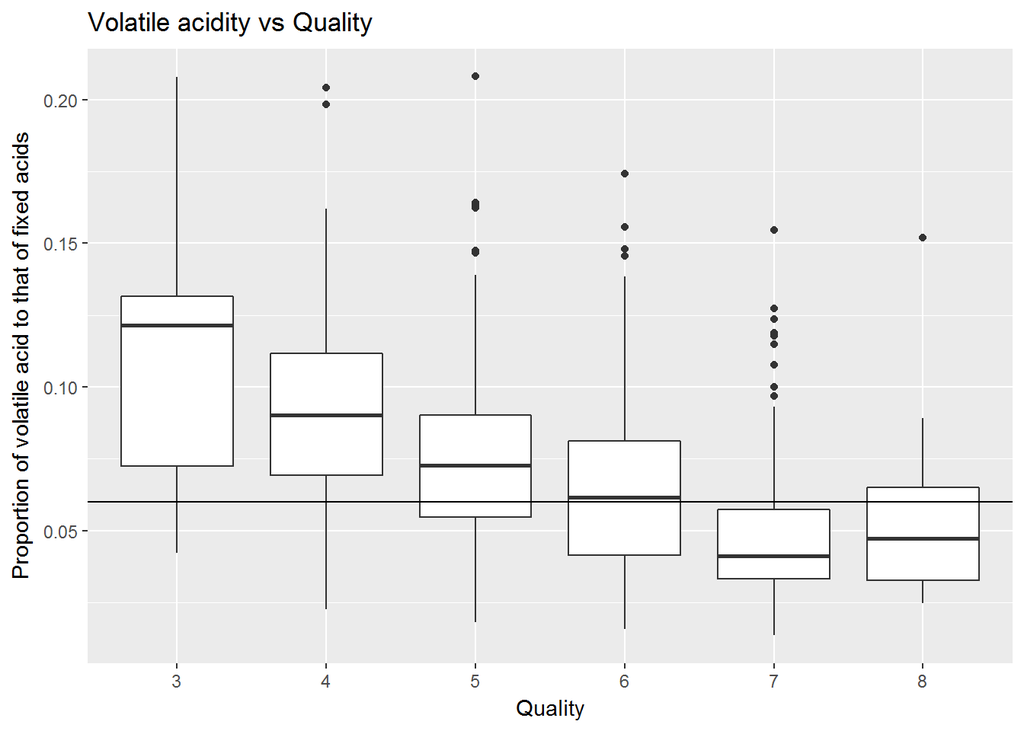

Most importantly, acetic acid does boil off when heated, and high VA is undesirable in a wine. A VA of 0.03-0.06% is produced during fermentation and is considered a normal level. And thus, now we got one factor which is making good quality wines good; as we can see quality 7 and 8 wines are having their most of the wines under desirable ranges and the median definitely within the range.

Since this is one of the important factors in red wines, thus this attribute values in the perfect range makes it of goood quality.

### Free Sulfur Dioxide vs Residual Sugar

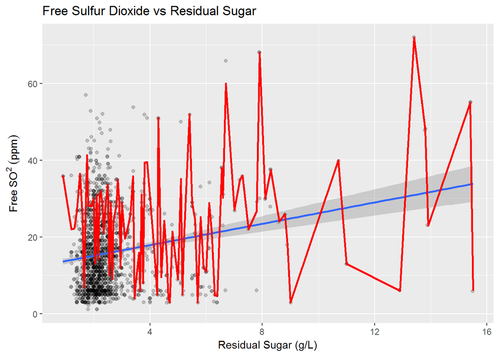

With the increase in residual sugar, more free SO2 is required since it binds with chemicals in wine, such as acetaldehyde and anthocyanins and even residual sugars. The fluctuating trends may be because the residual sugar might have already used up some of the free SO2.

### Free SO2 vs Quality Groups

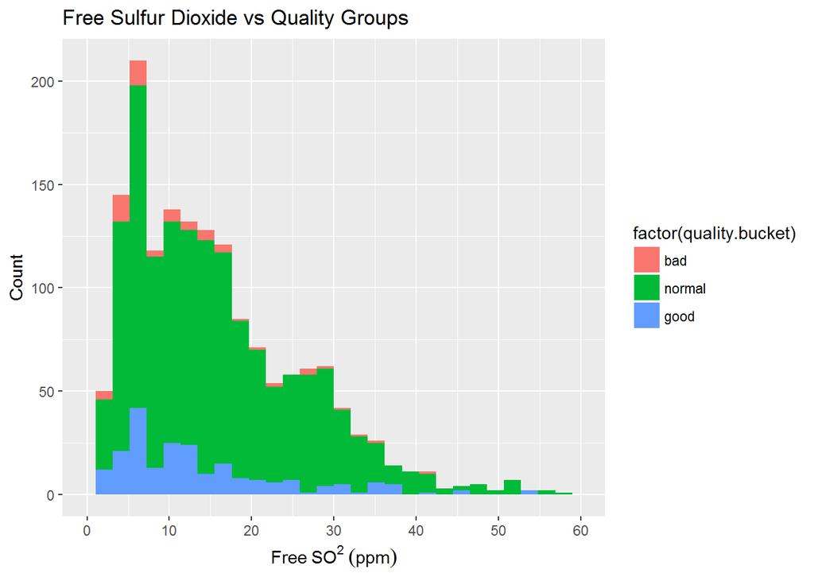

Most of the bound sulfur dioxide, which can be 50 - 90% of the amount of SO2 added, is not available to function as a preservative. It is part of the “Total SO2” in a wine, but is effectively of no use as a protectant against oxidation or against bacteria. That is why most measurements are for “Free SO2.”

High quality wines being more acidic are automatically protective against bacteria.

### Density vs Fixed acidity

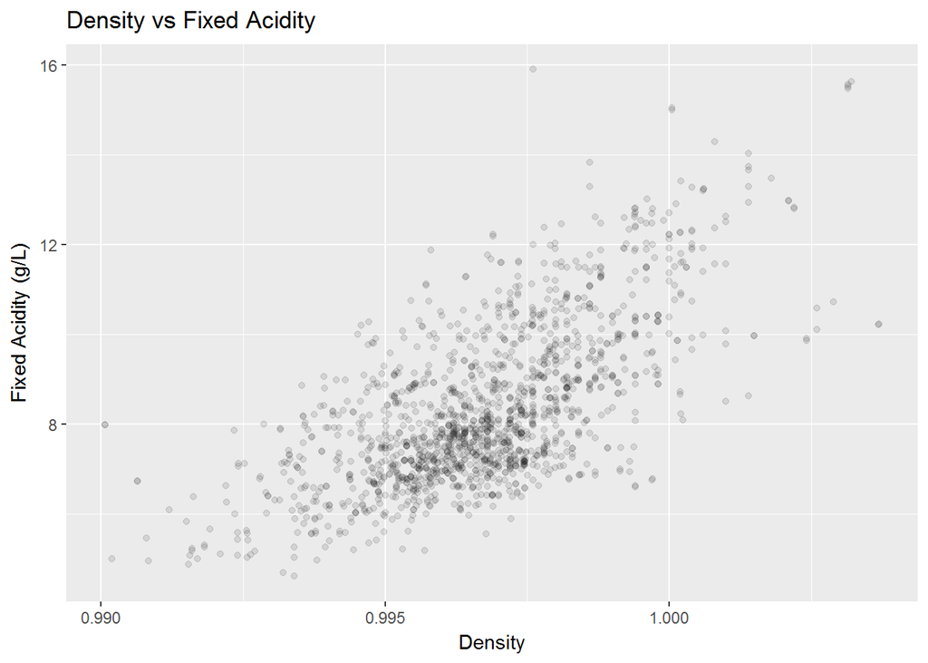

A blue-tinged rim on some wines correlate with lower acidity whereas a red-tinged rim correlates with higher acidity (low pH). When a very translucent wine is weak in color, it could be from a cooler region or from a light red wine.

Thus, more the acidity, more the density, and since it has been noticed in the previous plots that “good” quality wines were more acidic, thus it would also mean that they are denser too, which enhances their quality.

# Bivariate Analysis

### Talk about some of the relationships you observed in this part of the investigation. How did the feature(s) of interest vary with other features in the dataset?

- Wines falling under “good” quality bins are more acidic, but the proportion of volatile acid out of total acid content is just the within the desired range.
- The free SO2 required in the wine is directly proportional to the amount of residual sugar in the wine.
- But higher quality wines are having lower free SO2 content, this may be due to the residual sugar binding with free so2, thus making it inactive.

### Did you observe any interesting relationships between the other features (not the main feature(s) of interest)?

- Other features were pH and density.
- As stated above, pH will decrease with increase in acid content in the wine and thus “good” quality wines have lower pH, this helps to prevent microorganisms growth, thus enhancing their quality.
- Also, more acidity leads to more density and thus finer the quality becomes.

# Multivariate Plots Section

### Proportion of free SO2 to that of total SO2 vs Quality

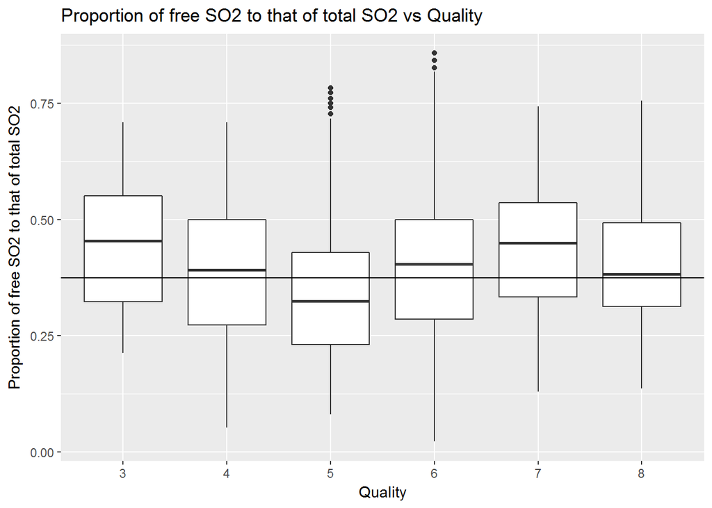

The higher the pH, the less SO2 will be in the useful free form and the less effective this free SO2 will be. Thus, here even though the free SO2 levels are higher in “bad” quality wines, the pH being higher in those will make free SO2 inactive and thus the wines with lower pH (higher acidity) fall under the category of “good” wines, where free SO2 will be in active state, to preserve the wines.

### Fixed acidity vs Residual Sugar and Quality

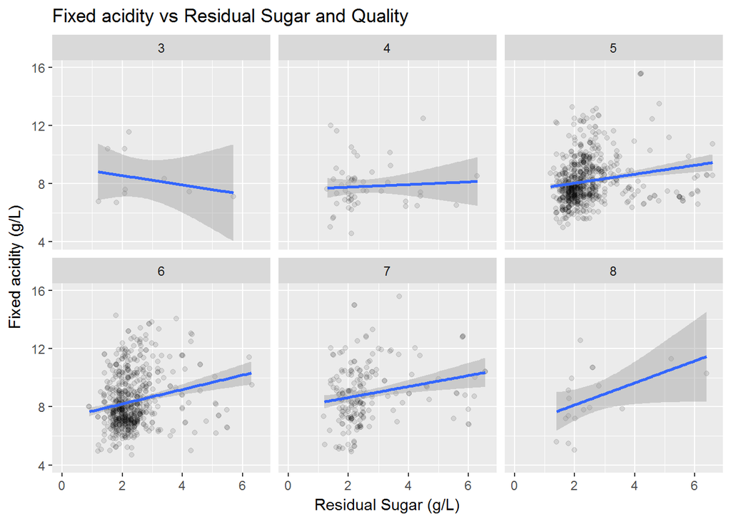

Warmer climates result in high sugar and low acid grapes whereas cooler climates result in low sugar and high acid grapes, and that’s how the resulting wine is.

The good quality wines are rich in residual sugars with increase in acidity and thus balancing the acidic taste of wines with the sweetness, whereas the poor quality wines are not able to maintain such balance as seen from the plot and hence the quality bin they come under is either “normal” or “bad”.

### Proprtion of free SO2 to total SO2 vs Residual Sugar and Quality

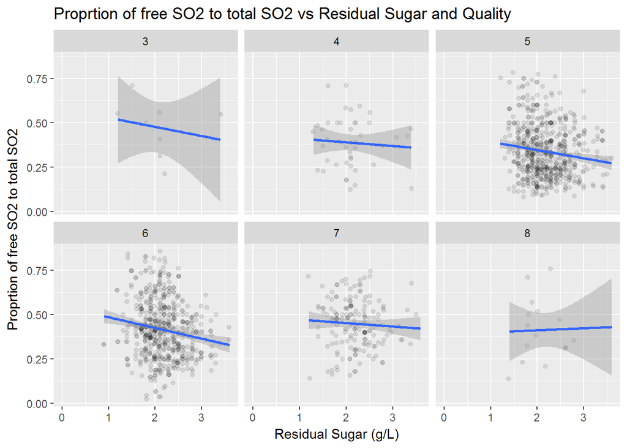

With increase in the residual sugar levels, free SO2 is decreasing in most the cases above. The reason behind this may be because of the residual sugar binding with free So2 with time. But since we have acidity dominating in good quality wines thus free SO2 has been stabilized. This is one more factor that makes such wines to count in “good” quality bins.

### Volatile Acidity and Citric acid (Non-volatile acid) vs Density and Quality

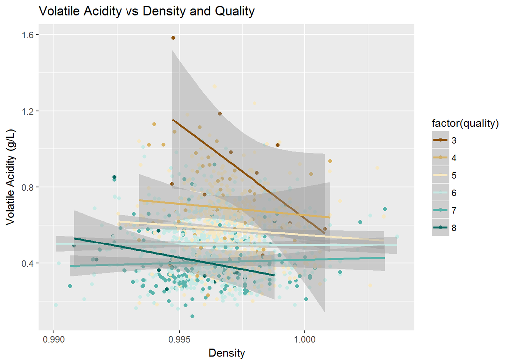

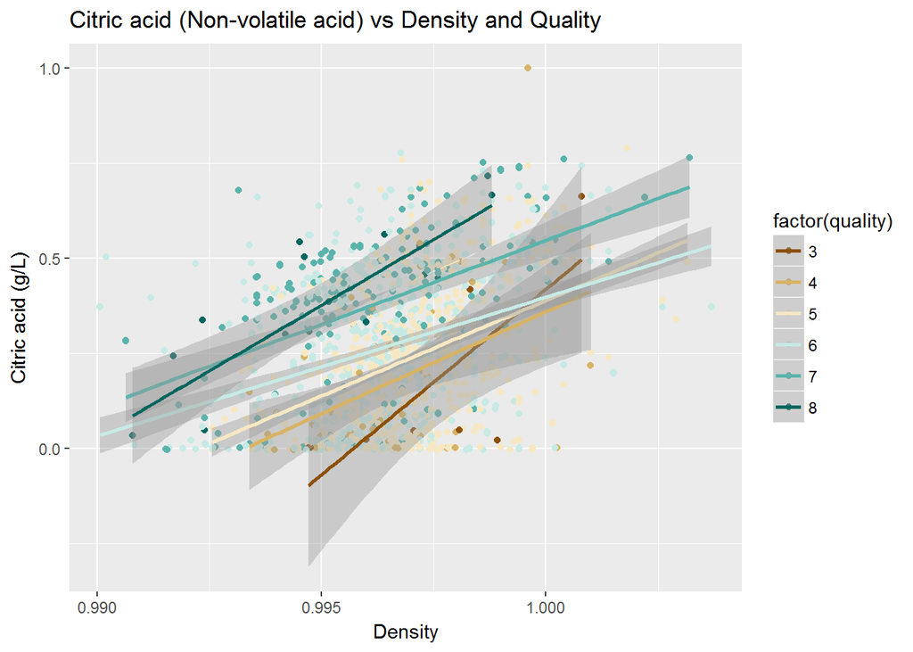

### Mathematical models suggested:

**Model 1: Relationship between residual sugar and non-volatile acids in red wine**

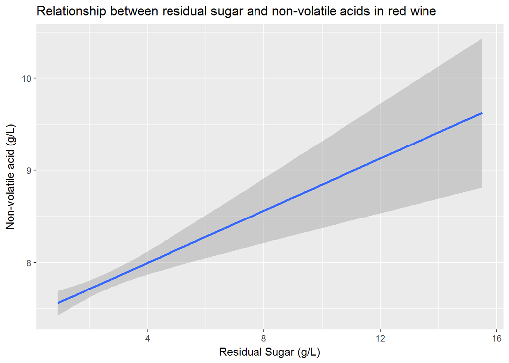

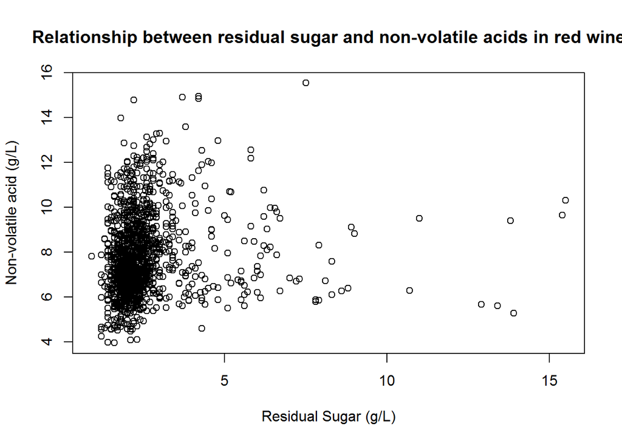

```
##
## Call:
## lm(formula = wine$fixed.acidity - wine$volatile.acidity ~ wine$residual.sugar)
##
## Coefficients:
##         (Intercept)  wine$residual.sugar
##              7.4326               0.1415
```

The red wines should be such that the acidity is low (but adequate enough to prevent bacteria growth) and the residual sugar is high (adequate enough to add sweetness to wine). But ideally, it is difficult to achieve, thus from the data above, the derived mathematical model is:

Acidity due to non-volatile acids = 0.1415 * residual sugar + 7.4326

Dry wines are typically in the 0.2-0.3 percent range, off-dry wines in the 1.0-5.0 percent range, and sweet dessert wines in the 5.0-15 percent range.

**Model 2: Amount of free SO2 in red wine**

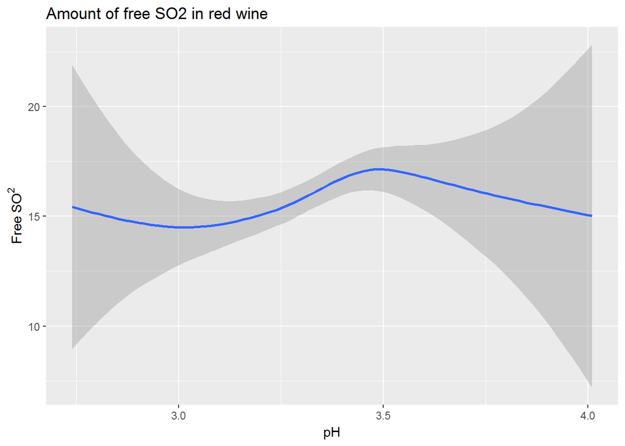